# Annabel Lee

Susan Vanderplas

6/28/2021

## Annabel Lee

Read in the lines of text in “The Annabel Lee” and write code to do the following tasks:

1. Create a tibble with a column that contains the lines of the poem (leave the blank lines in for now)
2. Count the number of words in each line. Do you see any patterns?
3. Can you use this information to create a variable with stanza numbers?
4. Create a column with line numbers (within each stanza)
5. Split the lines of the poem into words (you can discard punctuation). Is there any discernible pattern?

```r
library(tidyverse)
```

```r
poem_lines <- readLines("annabel_lee_poe.txt")
poem <- tibble(lines = poem_lines) %>%
  # This looks for a letter + a space (of any sort, so an end-line counts) or
  # punctuation (last word of a line ends with e.g. a period or comma)
  mutate(n_words = str_count(lines, "([A-z][[:space:][:punct:]])")) %>%
  # 0-word lines mark the end of a stanza...
  mutate(stanza = cumsum(n_words == 0) + 1) %>%
  # Create an overall line number
  mutate(overall_line = 1:n()) %>%
  # Now we can get rid of lines with 0 words
  filter(n_words > 0) %>%
  # We can group by stanza and count the lines within each stanza
  group_by(stanza) %>%
  mutate(stanza_line = 1:n())

# Words
poem_words <- poem %>%
  mutate(words = str_split(lines, "[[:space:][:punct:]]", simplify = F)) %>%
  unnest(c(words)) %>%
  # Require words to have some non-space character
  filter(nchar(str_trim(words)) > 0) %>%
  # For each line, group by line number and calculate the word number
  group_by(overall_line) %>%
  mutate(word_num = 1:n())
```

We can use some exploratory plots to see some of the patterns within the structure of the poem…

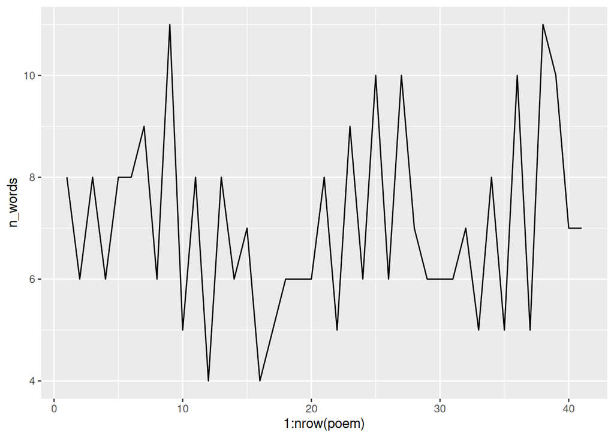

```r
ggplot(poem, aes(x = 1:nrow(poem), y = n_words)) + geom_line()
```

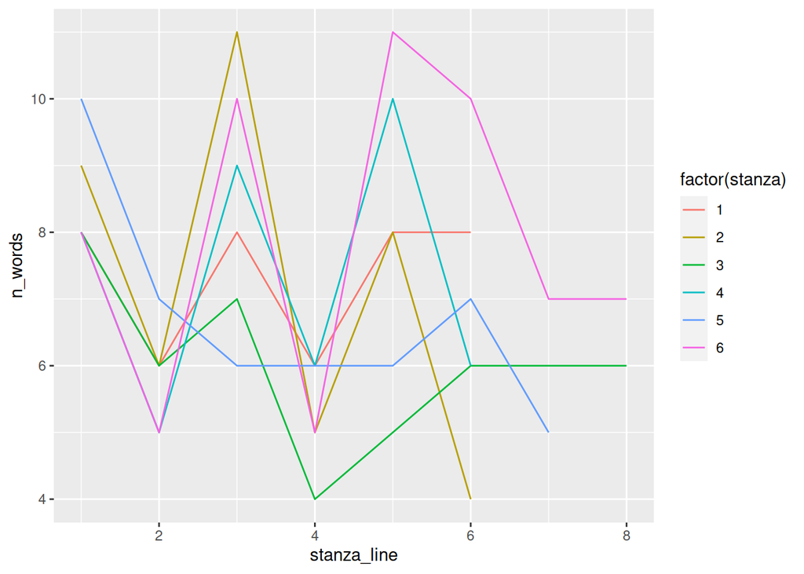

```r
ggplot(poem, aes(x = stanza_line, y = n_words, color = factor(stanza))) + geom_line()
```

Here, it looks like there is generally a pattern of long line-short-line, with the notable exception of Stanza 5.

When we explore the words, we have lots of options:

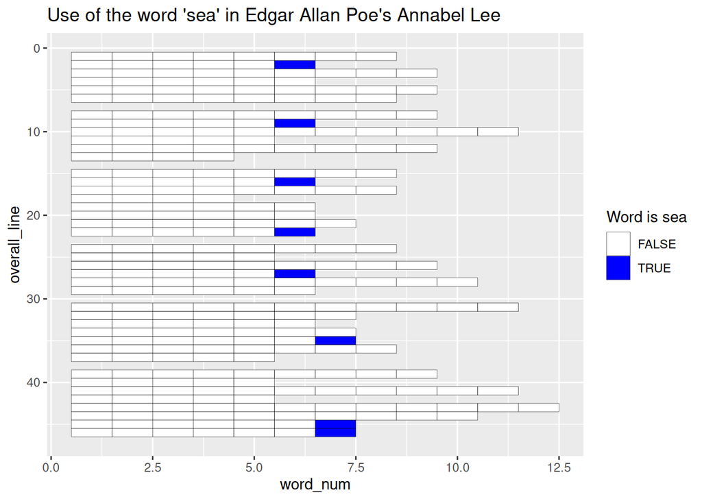

```r
ggplot(poem_words, aes(x = word_num, y = overall_line,
                       fill = str_detect(words, "sea"))) +
  geom_tile(color = "black") +
  scale_fill_manual("Word is sea", values = c("FALSE" = "white", "TRUE" = "blue")) +
  # Make the tiles start at the top for line 1, like we would read in a poem
  scale_y_reverse() +
  ggtitle("Use of the word 'sea' in Edgar Allan Poe's Annabel Lee")
```

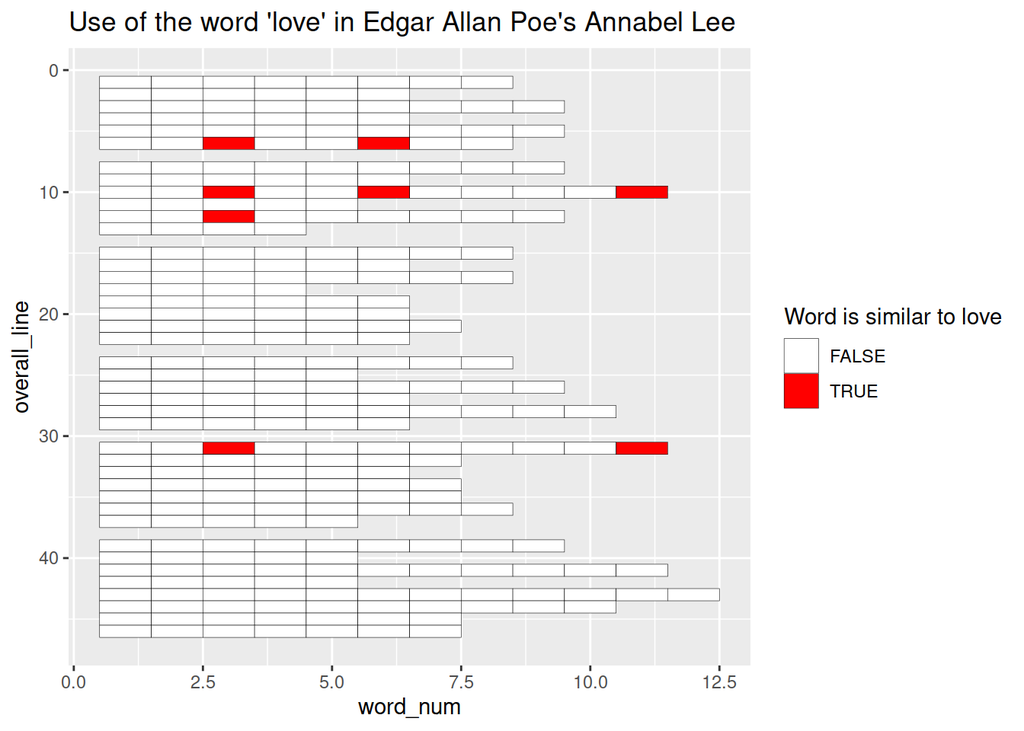

```r
ggplot(poem_words, aes(x = word_num, y = overall_line,
                       fill = str_detect(words, "love.*"))) +
  geom_tile(color = "black") +
  scale_fill_manual("Word is similar to love", values = c("FALSE" = "white", "TRUE" = "red")) +
  # Make the tiles start at the top for line 1, like we would read in a poem
  scale_y_reverse() +
  ggtitle("Use of the word 'love' in Edgar Allan Poe's Annabel Lee")
```

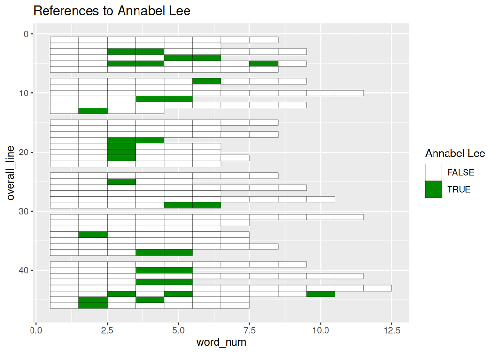

```r
ggplot(poem_words, aes(x = word_num, y = overall_line,
                       fill = str_detect(words, "Annabel|Lee|maiden|her|she|darling|bride"))) +
  geom_tile(color = "black") +
  scale_fill_manual("Annabel Lee", values = c("FALSE" = "white", "TRUE" = "green4")) +
  # Make the tiles start at the top for line 1, like we would read in a poem
  scale_y_reverse() +
  ggtitle("References to Annabel Lee")
```

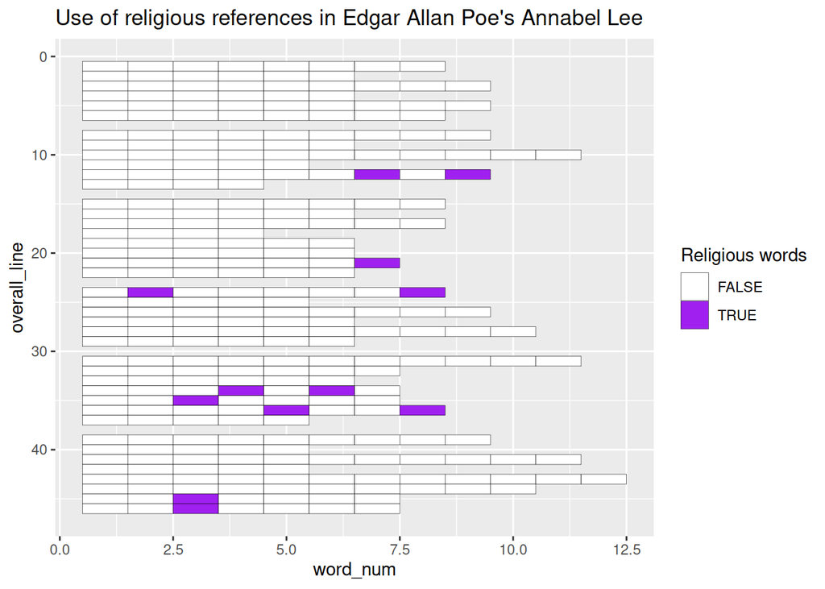

```r
religious_words <- c("Heaven", "seraph", "sepulchre", "angels", "demons", "soul", "tomb") %>%
  paste(collapse = "|")

ggplot(poem_words, aes(x = word_num, y = overall_line,
                       fill = str_detect(words, religious_words))) +
  geom_tile(color = "black") +
  scale_fill_manual("Religious words", values = c("FALSE" = "white", "TRUE" = "purple")) +
  # Make the tiles start at the top for line 1, like we would read in a poem
  scale_y_reverse() +
  ggtitle("Use of religious references in Edgar Allan Poe's Annabel Lee")
```

I’ve created a tile plot that shows what type of word we’re looking at. In simple cases (‘sea’), we can look for a single word, but in some cases (things referencing Annabel Lee) we have to look for multiple words – so we join them together with ‘|’, which is “or” when dealing with strings.

We could, of course, interpret each of these patterns in the poetic sense, but for now, the patterns themselves are interesting enough.